# Vector Data

### A first look: loading and plotting US counties

The cell below opens the US counties shapefile, prints basic metadata, and plots the layer: a minimal end-to-end example of the GeoLattice vector workflow you will build on throughout this module.

```python
# Open the US counties shapefile and print basic GeoDataFrame metadata.
counties_path = ROOT / "Data" / "00_shared" / "vector_data" / "USA" / "US_COUNTY.shp"  # Path to counties shapefile
counties = gpd.read_file(counties_path)  # Read shapefile into a GeoDataFrame

# Basic metadata for the counties layer
print(f"Feature count : {len(counties):,}")  # Number of county features
print(f"Geometry type : {counties.geom_type.unique().tolist()}")  # Distinct geometry types present
print(f"CRS           : {counties.crs}")  # Coordinate reference system
print(f"Bounding box  : {counties.total_bounds.round(4).tolist()}")  # Layer extent [minx, miny, maxx, maxy]
print(f"\nColumns:\n{list(counties.columns)}")  # Attribute and geometry column names
counties.head(3)  # Preview the first three attribute rows
```

```
Feature count : 3,108
Geometry type : ['Polygon', 'MultiPolygon']
CRS           : PROJCS["NAD_1983_Albers",GEOGCS["NAD83",DATUM["North_American_Datum_1983",SPHEROID["GRS 1980",6378137,298.257222101,AUTHORITY["EPSG","7019"]],AUTHORITY["EPSG","6269"]],PRIMEM["Greenwich",0],UNIT["Degree",0.0174532925199433]],PROJECTION["Albers_Conic_Equal_Area"],PARAMETER["latitude_o…
Bounding box  : [-2356113.7429, 268091.2188, 2258200.1769, 3172567.9206]

Columns:
['FIPS', 'x', 'y', 'REGION_ID', 'DIVISION_I', 'STATE_ID', 'COUNTY_ID', 'REGION', 'DIVISION', 'STATE', 'COUNTY', 'geometry']
```

|  | FIPS | x | y | REGION_ID | DIVISION_I | STATE_ID | COUNTY_ID | REGION | DIVISION | STATE | COUNTY | geometry |
| --- | --- | --- | --- | --- | --- | --- | --- | --- | --- | --- | --- | --- |
| 0 | 1059.0 | 7.427660e+05 | 1296358.466 | 3.0 | 6.0 | 1.0 | 59.0 | South | East South Central | Alabama | Franklin County | POLYGON ((714018.351 1287004.948, 714023.415 1... |
| 1 | 13111.0 | 1.056524e+06 | 1376613.190 | 3.0 | 5.0 | 13.0 | 111.0 | South | South Atlantic | Georgia | Fannin County | POLYGON ((1037682.266 1388266.997, 1037756.908... |
| 2 | 19109.0 | 1.449645e+05 | 2246831.972 | 2.0 | 4.0 | 19.0 | 109.0 | Midwest | West North Central | Iowa | Kossuth County | POLYGON ((125348.861 2279627.32, 129553.742 22... |

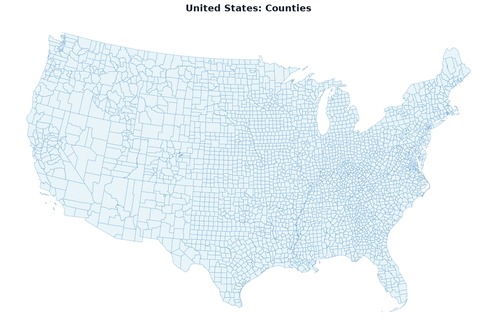

```
Plotted 3,108 county polygons.
```

```python
# Plot all US county polygons with a light fill and thin blue outlines.
fig, ax = plt.subplots(figsize=(14, 8))  # Wide figure for a national map
counties.plot(
    ax=ax,  # Draw onto the axes created above
    color="#e8f4f8",  # Light blue fill for county polygons
    edgecolor="#4a90c4",  # Medium blue outline color
    linewidth=0.3,  # Thin boundaries so dense counties stay readable
)
ax.set_title("United States: Counties", fontsize=16, fontweight="bold", pad=12)  # Map title
ax.set_xlabel("Longitude")  # Geographic X axis label
ax.set_ylabel("Latitude")  # Geographic Y axis label
ax.axis("off")  # Hide spines and ticks for a cleaner map
plt.tight_layout()  # Reduce unused margins
plt.show()  # Render the figure in the notebook
print(f"Plotted {len(counties):,} county polygons.")  # Confirm feature count drawn
```

## 7. Suggested Learning Path

The sub-notebooks are designed to be **self-contained** but build on each other naturally. Two recommended sequences:

### Path A: Sequential (Recommended for beginners)

Work through every notebook in order. Each notebook introduces one layer of the stack and prepares you for the next.

```
01.01 Read / Write  →  01.02 CRS  →  01.03 Visualise  →  01.04 Geoprocessing  →  01.05 Geometry Ops
```

### Path B: Task-Oriented (For practitioners with some GIS experience)

Jump directly to the notebook that matches your immediate need:

| Goal | Start here |
| --- | --- |
| Load a Shapefile / GeoJSON / GeoParquet | 01.01 |
| Fix a CRS mismatch or reproject a layer | 01.02 |
| Make a choropleth or interactive web map | 01.03 |
| Clip, buffer, dissolve, or spatially join layers | 01.04 |
| Create or clean individual geometries | 01.05 |

### Estimated Time

| Notebook | Topic | Est. Time |
| --- | --- | --- |
| 01.00 | This overview | 20 min |
| 01.01 | Reading and Writing | 1.5-2 h |
| 01.02 | Map Projections and CRS | 1-1.5 h |
| 01.03 | Visualisation | 1.5-2 h |
| 01.04 | Geoprocessing | 2-2.5 h |
| 01.05 | Geometry Operations | 1.5-2 h |
| **Total** |  | **~8-10 h** |

## Summary

Module 01 of GeoLattice provides a **complete, practitioner-oriented introduction to vector data** structured around five core workflows:

| # | Sub-notebook | Core Library | What you can do after |
| --- | --- | --- | --- |
| 01.01 | Read / Write | GDAL/OGR, Fiona | Load any vector format; export to Shapefile, GeoJSON, GeoPackage, and more |
| 01.02 | CRS & Projections | PyProj, GeoPandas | Inspect, assign, and reproject vector layers confidently |
| 01.03 | Visualisation | Matplotlib, Folium | Make publication-quality static maps and interactive web maps |
| 01.04 | Geoprocessing | GeoPandas, Shapely | Clip, buffer, dissolve, intersect, and join vector layers |
| 01.05 | Geometry Operations | Shapely 2.x | Create, transform, clean, and measure individual geometries |

All sub-modules share a consistent design philosophy: **GeoDataFrame-first**, **CRS-aware**, and **GDAL-backed**. Together they build the spatial data skills needed as a foundation for Module 02 (Raster Data) and Module 03 (Spatial Analysis).

*Happy mapping! 🗺️*